# Estimate immune cell proportions in tumor samples

Stephanie Hickey

2024-11-14

# Project Summary

Here we use single-cell RNA-seq data from primary osteosarcoma in 6 treatment-naïve dogs ([Ammons et al, Commun Biol. 2024 Apr 24](https://www.nature.com/articles/s42003-024-06182-w)) as a reference data set to estimate immune cell proportions in bulk tumor samples and cell lines using parallel methods [MuSiC](https://xuranw.github.io/MuSiC/articles/MuSiC.html), [SCDC](https://meichendong.github.io/SCDC/articles/SCDC.html#scdc-pre-process-of-scrna-seq-data-1), and [DWLS](https://cran.r-project.org/web/packages/DWLS/index.html).

The following cell types are included in the reference data. Osteoblast and Osteoclasts were removed.

1. TAM
2. T cell
3. Endothelial cell
4. T_cycling
5. B cell
6. Neutrophil
7. IFN-TAM
8. Fibroblast
9. T_IFN
10. DC
11. NK
12. Mast cell
13. TIM

Both MuSiC and SCDC are commonly used tools that take advantage of multi-subject reference data sets by appropriately weighting genes showing cross-subject and cross-cell consistency, though they use slightly different algorithms. DWLS does not consider multiple subjects but shows improved performance compared with MuSiC and SCDC using a single-subject reference in a recent [benchmarking study](https://www.biorxiv.org/content/10.1101/2024.06.10.598226v1.full).

## Comparison of tool performace using pseudobulk samples.

To test how well these tools work with this reference data set, I created 100 pseudobulk samples by randomly selecting 3K (of ~18K) cells from each of the listed cell types in varying proportions.I’ve compared the known proportions with the predicted proportions from each tool below.

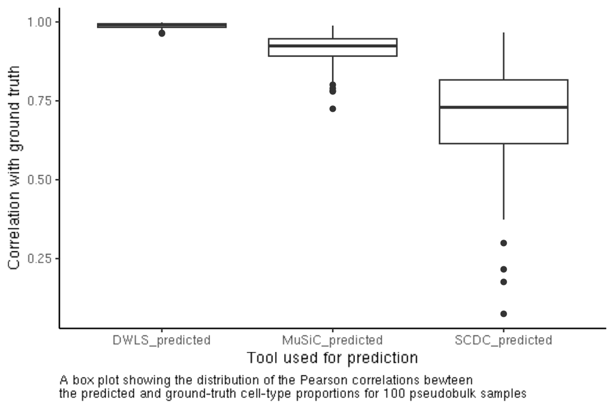

| var1 | MedianCorrelation | MeanCorrelation |
| --- | --- | --- |
| DWLS_predicted | 0.9906326 | 0.9877174 |
| MuSiC_predicted | 0.9239791 | 0.9124079 |
| SCDC_predicted | 0.7294355 | 0.6989894 |

Cell-type proportion predictions made using DWLS show the best correlation with the ground truth cell-type proportions for each sample.

## Sample deconvolution using DWLS

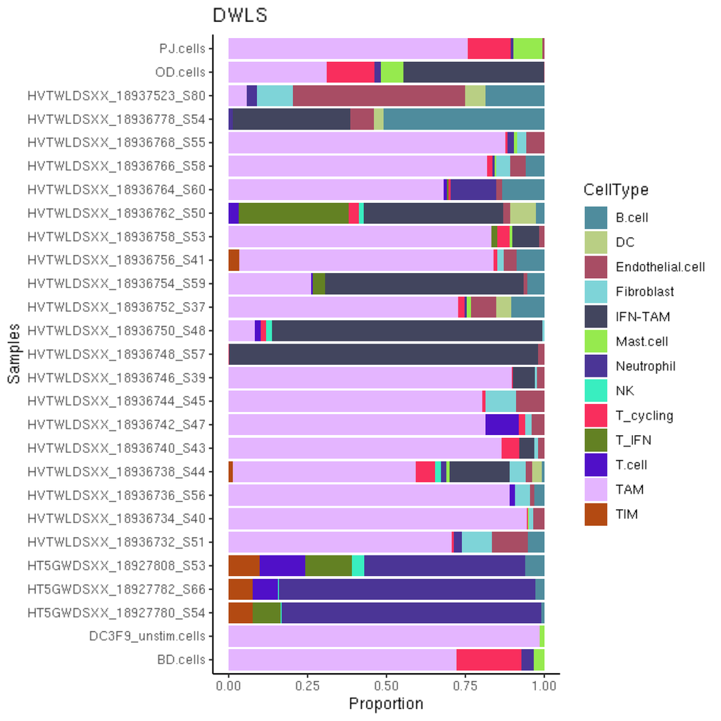

|  | Samples | CellType | Proportion | Tool |
| --- | --- | --- | --- | --- |
| 1 | HT5GWDSXX_18927780_S54 | B.cell | 0.01 | DWLS |
| 2 | HT5GWDSXX_18927780_S54 | DC | 0 | DWLS |
| 3 | HT5GWDSXX_18927780_S54 | Endothelial.cell | 0 | DWLS |
| 4 | HT5GWDSXX_18927780_S54 | Fibroblast | 0 | DWLS |
| 5 | HT5GWDSXX_18927780_S54 | IFN-TAM | 0 | DWLS |
| 6 | HT5GWDSXX_18927780_S54 | Mast.cell | 0 | DWLS |
| 7 | HT5GWDSXX_18927780_S54 | Neutrophil | 0.82 | DWLS |
| 8 | HT5GWDSXX_18927780_S54 | NK | 0 | DWLS |
| 9 | HT5GWDSXX_18927780_S54 | T.cell | 0 | DWLS |
| 10 | HT5GWDSXX_18927780_S54 | T_cycling | 0 | DWLS |

[output cut: 341 more lines]